# Theme

Data Visualization - Part 7

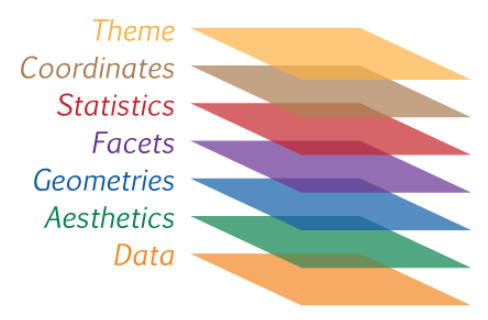

### ggthemes

First let’s look at a simple scatterplot made by `geom_point()` and with no themes:

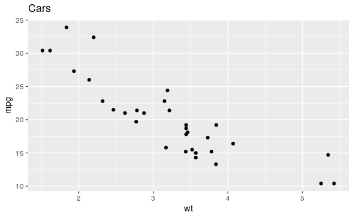

```r
p <- ggplot(mtcars, aes(x = wt, y = mpg)) +
  geom_point() +
  ggtitle("Cars")
p
```

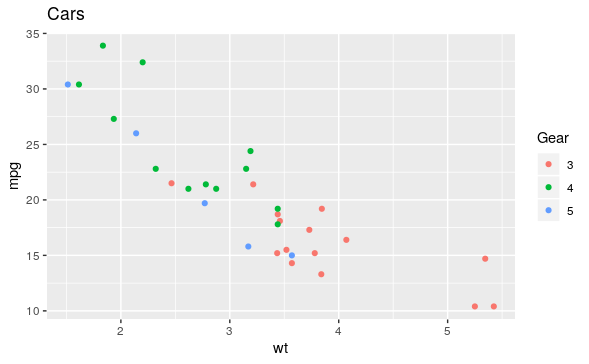

```r
p2 <- ggplot(mtcars, aes(x = wt, y = mpg, color = factor(gear))) +
  geom_point() +
  labs(title = "Cars", color = "Gear")
p2
```

#### Tufte theme and geoms

Minimal theme and geoms based on plots in The Visual Display of Quantitative Information.

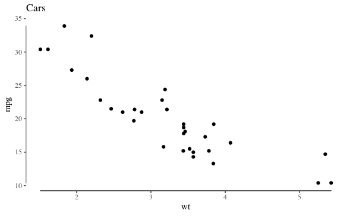

```r
p + geom_rangeframe() +
  theme_tufte()
```

#### Economist theme

A theme that approximates the style of plots in The Economist magazine.

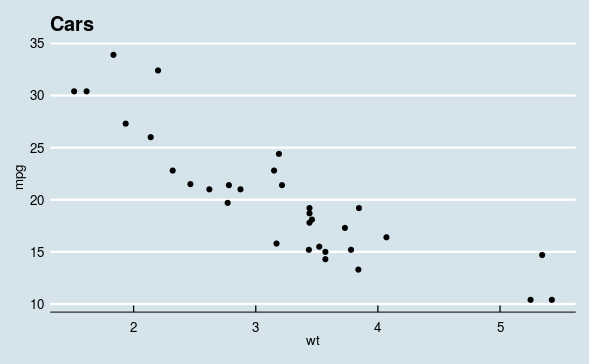

```r
p + theme_economist() + scale_colour_economist()
```

#### Excel 2003 theme

For that classic ugly look and feel

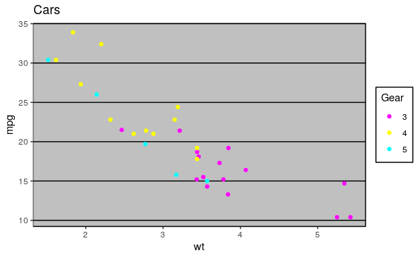

```r
p2 + theme_excel() + scale_colour_excel()
```

#### Wall Street Journal

Theme and some color palettes based on plots in the The Wall Street Journal.

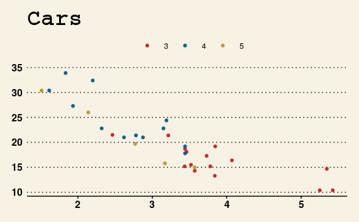

```r
p2 + theme_wsj() + scale_colour_wsj("colors6", "")
```

### Create your own theme

```r
blank_theme <- theme_minimal() +
  theme(
    axis.title.x = element_blank(),
    axis.title.y = element_blank(),
    panel.grid = element_blank(),
    plot.title = element_text(size=14, face="bold")
    )
```

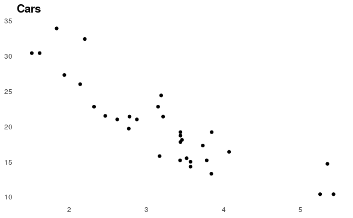

```r
p + blank_theme
```

## Template for layered grammar of graphics

> `ggplot(data = <DATA>) + <GEOM_FUNCTION>( mapping = aes(<MAPPINGS>), stat = <STAT>, position = <POSITION> ) + <COORDINATE_FUNCTION> + <FACET_FUNCTION>`

In practice, you rarely need to supply all seven parameters to make a graph because ggplot2 will provide useful defaults for everything except the data, the mappings, and the geom function.

## More Examples

**Bar Chart** from [Top 50 ggplot2 Visualizations](http://r-statistics.co/Top50-Ggplot2-Visualizations-MasterList-R-Code.html).

We saw how to create a bar chart with `geom_bar()`. By default `geom_bar()` will use `stat = "count"`, so we don’t need to provide a `y`, it’s being calculated as the count of points in each bin. In order to create a bar chart with a given `y` value we need to set `stat=identity` and provide both `x` and `y` inside `aes()` `x` is either character or factor and `y` is numeric.

```r
# create a frequency table
freqtable <- table(mpg$manufacturer)
df <- as.data.frame.table(freqtable)
head(df)
```

|  | Var1 | Freq |
| --- | --- | --- |
| 1 | audi | 18 |
| 2 | chevrolet | 19 |
| 3 | dodge | 37 |
| 4 | ford | 25 |
| 5 | honda | 9 |
| 6 | hyundai | 14 |

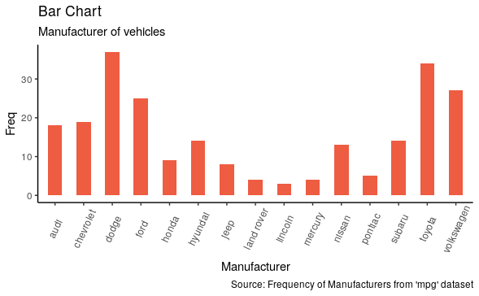

```r
ggplot(df, aes(Var1, Freq)) +
  geom_bar(stat="identity", width = 0.5, fill="tomato2") +
  labs(title="Bar Chart",
       subtitle="Manufacturer of vehicles",
       caption="Source: Frequency of Manufacturers from 'mpg' dataset",
       x = "Manufacturer") +
  theme_classic() +
  theme(axis.text.x = element_text(angle=65, vjust=0.6))  # to give x labels an angle for readability
```

**Email Campaign Funnel** from [Top 50 ggplot2 Visualizations](http://r-statistics.co/Top50-Ggplot2-Visualizations-MasterList-R-Code.html):

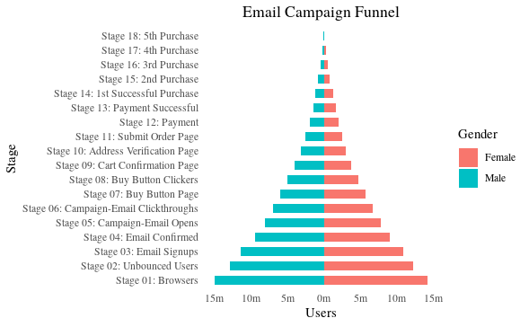

```r
options(scipen = 999)  # turns off scientific notations like 1e+40
options(repr.plot.width=7, repr.plot.height=5)  # Modifying the chart size

# Read data
options(readr.num_columns = 0)  # turns off messages printed by read_csv
email_campaign_funnel <- read_csv("https://raw.githubusercontent.com/selva86/datasets/master/email_campaign_funnel.csv")

# X Axis Breaks and Labels
brks <- seq(-15000000, 15000000, 5000000)
lbls = paste0(as.character(c(seq(15, 0, -5), seq(5, 15, 5))), "m")

# Plot
ggplot(email_campaign_funnel, aes(x = Stage, y = Users, fill = Gender)) +   # Fill column
                              geom_bar(stat = "identity", width = .6) +   # draw the bars
                              scale_y_continuous(breaks = brks,   # Breaks
                                                 labels = lbls) + # Labels
                              coord_flip() +  # Flip axes
                              labs(title = "Email Campaign Funnel") +
                              theme_tufte() +  # Tufte theme from ggfortify
                              theme(plot.title = element_text(hjust = .5),
                                    axis.ticks = element_blank())  # Centre plot title
```

### Line chart

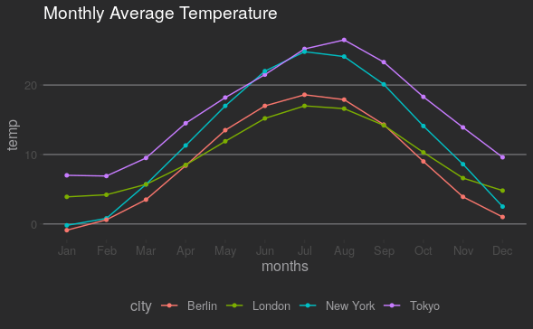

```r
dtemp <- data.frame(months = factor(rep(substr(month.name,1,3), 4), levels = substr(month.name,1,3)),
                    city = rep(c("Tokyo", "New York", "Berlin", "London"), each = 12),
                    temp = c(7.0, 6.9, 9.5, 14.5, 18.2, 21.5, 25.2, 26.5, 23.3, 18.3, 13.9, 9.6,
                             -0.2, 0.8, 5.7, 11.3, 17.0, 22.0, 24.8, 24.1, 20.1, 14.1, 8.6, 2.5,
                             -0.9, 0.6, 3.5, 8.4, 13.5, 17.0, 18.6, 17.9, 14.3, 9.0, 3.9, 1.0,
                             3.9, 4.2, 5.7, 8.5, 11.9, 15.2, 17.0, 16.6, 14.2, 10.3, 6.6, 4.8))

temp <- ggplot(dtemp, aes(x = months, y = temp, group = city, color = city)) +
  geom_line() +
  geom_point(size = 1.1) +
  ggtitle("Monthly Average Temperature") +
  theme_hc(style = "darkunica") +
  scale_fill_hc("darkunica")
temp
```

# Interactive plotting with Plotly

We can use package **plotly** on top of a ggplot plot to create interactive charts. Plotly is a powerful tool for creating interactive dashboards and plots and there are different ways to use it. Here we will only show how to make ggplots into a plotly by using `ggplotly()` function. For more information about other ways to leverage this package go to [ploy.ly](https://plot.ly/).

## Scatterplot

Let’s use the most recent plot we created with WSJ theme as an example:

```r
ggplotly(p2 + theme_wsj() + scale_colour_wsj("colors6", ""))  # Same plot with ggplotly()
```

[interactive chart not shown]

## Time Series

Using `geom_line()`, a time series (or line chart) can be drawn. Data: `economics` from ggplot2.

```r
head(economics)
```

| date | pce | pop | psavert | uempmed | unemploy |
| --- | --- | --- | --- | --- | --- |
| 1967-07-01 | 506.7 | 198712 | 12.6 | 4.5 | 2944 |
| 1967-08-01 | 509.8 | 198911 | 12.6 | 4.7 | 2945 |
| 1967-09-01 | 515.6 | 199113 | 11.9 | 4.6 | 2958 |
| 1967-10-01 | 512.2 | 199311 | 12.9 | 4.9 | 3143 |
| 1967-11-01 | 517.4 | 199498 | 12.8 | 4.7 | 3066 |
| 1967-12-01 | 525.1 | 199657 | 11.8 | 4.8 | 3018 |

```r
ts_plot <- ggplot(economics, aes(x=date)) +
geom_line(aes(y=psavert)) +
  labs(title="US economic time series",
       subtitle = "Personal Savings Rate",
       caption="Source: Economics",
       y="Savings Rate %") +
  theme_classic()

ggplotly(ts_plot)  # Same plot with ggplotly()
```

[interactive chart not shown]

## Bar chart

```r
bar_plot <- ggplot(data = diamonds) +
  geom_bar(mapping = aes(x = cut, fill = clarity), position = "dodge") +
  scale_fill_manual(values = c("#41f4f4", "#41d9f4", "#41bbf4", "#418ef4", "#415ef4", "#6a41f4", "#9741f4", "#f441f1"))

ggplotly(bar_plot)  # Same plot with ggplotly()
```

[interactive chart not shown]

# Additional Recourses

- Examples of elaborate charts: [Top 50 ggplot2 Visualizations](http://r-statistics.co/Top50-Ggplot2-Visualizations-MasterList-R-Code.html)
- To go beyond ggplot2 functionalities check out these extensions: [ggplot2 extensions](http://www.ggplot2-exts.org/gallery/)
- *ggplot2-cheatsheet.pdf* in the cheatsheets directory
- Hex color
  - Simply google “hex color picker” and use Google’s tool
- Themes
  - ggthemes - Examples [here](https://mran.microsoft.com/snapshot/2016-12-03/web/packages/ggthemes/vignettes/ggthemes.html)
  - ggtech